# StatData1: forel190930

Anders Tolver

# Eksempel med elektriske ål

Formålet med eksemplet er at illustrere

- at der kan være variable i et datasæt, som både kan indgå som faktor (kategorisk variabel) og som kontinuert (kvantitativ variabel) i en statistisk model
- hvordan man kan *teste* om det er rimeligt at lade middelværdien være en lineær funktion af den forklarende variabel (som fx. i en lineær regressionsmodel)

## Indlæsning og visualisering af data

Datasættet `eels` ligger is `isdals` R-pakken

```r
library(isdals)
data(eels)
head(eels)
```

```
##   temp freq
## 1   20  230
## 2   20  239
## 3   20  251
## 4   22  256
## 5   22  259
## 6   22  265
```

Data består af sammenhørende værdier af vandtemperatur (`temp`) og frekvensen (`freq`) af de elektriske signaler, som ålen udsender.

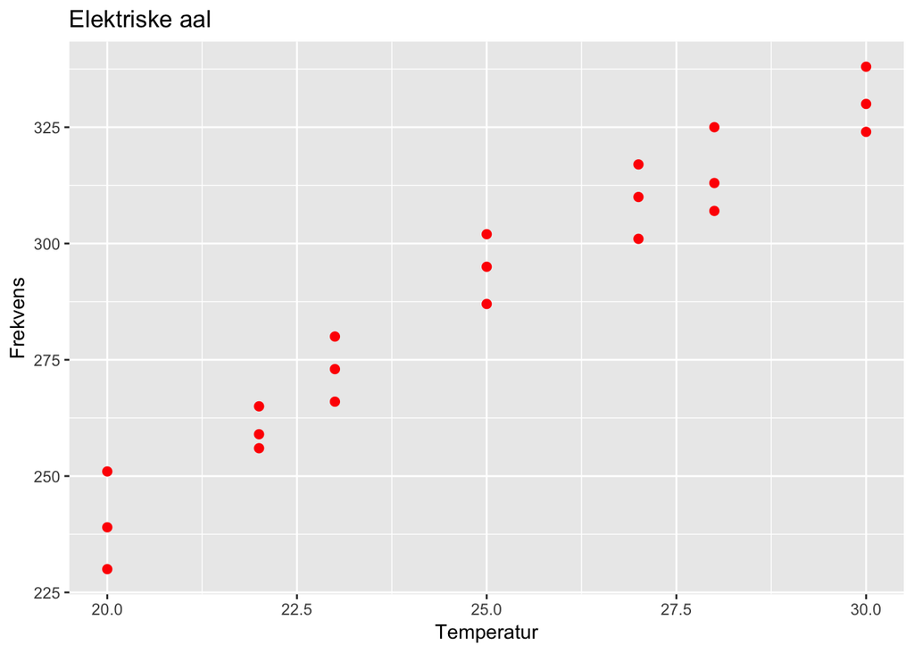

```r
ggplot(data = eels) + geom_point(aes(x = temp, y = freq), color = "red", size = 2) + labs(x = "Temperatur", y = "Frekvens", title = "Elektriske aal")
```

## Lineær regression og ensidet ANOVA

Plottet ovenfor lægger op til en lineær regression.

```r
linreg <- lm(freq ~ temp, data=eels)
summary(linreg)$coefficients
```

```
##              Estimate Std. Error   t value     Pr(>|t|)
## (Intercept) 61.649749 12.6430867  4.876163 1.048924e-04
## temp         9.092105  0.5013873 18.133896 1.874721e-13
```

Men **eftersom der er gentagelser for hver temperatur** så er det også en mulighed at lave ensidet ANOVA.

Når vi laver ANOVA, skal vi huske at bruge temperaturevariablen om til en kategorisk variabel (faktor).

```r
eels <- transform(eels, tempFac = factor(temp))
ensidet <- lm(freq ~ tempFac, data=eels)
summary(ensidet)$coefficients
```

```
##              Estimate Std. Error   t value     Pr(>|t|)
## (Intercept) 240.00000   4.551295 52.732245 1.662044e-17
## tempFac22    20.00000   6.436503  3.107277 7.719984e-03
## tempFac23    33.00000   6.436503  5.127008 1.538561e-04
## tempFac25    54.66667   6.436503  8.493225 6.778786e-07
## tempFac27    69.33333   6.436503 10.771895 3.691005e-08
## tempFac28    75.00000   6.436503 11.652290 1.362950e-08
## tempFac30    90.66667   6.436503 14.086324 1.165463e-09
```

## Modelkontrol

Som vi lærte i sidste uge, så foretages modelkontrol primært ved at se på residualplot og QQ-plot.

### For lineær regressionsmodel

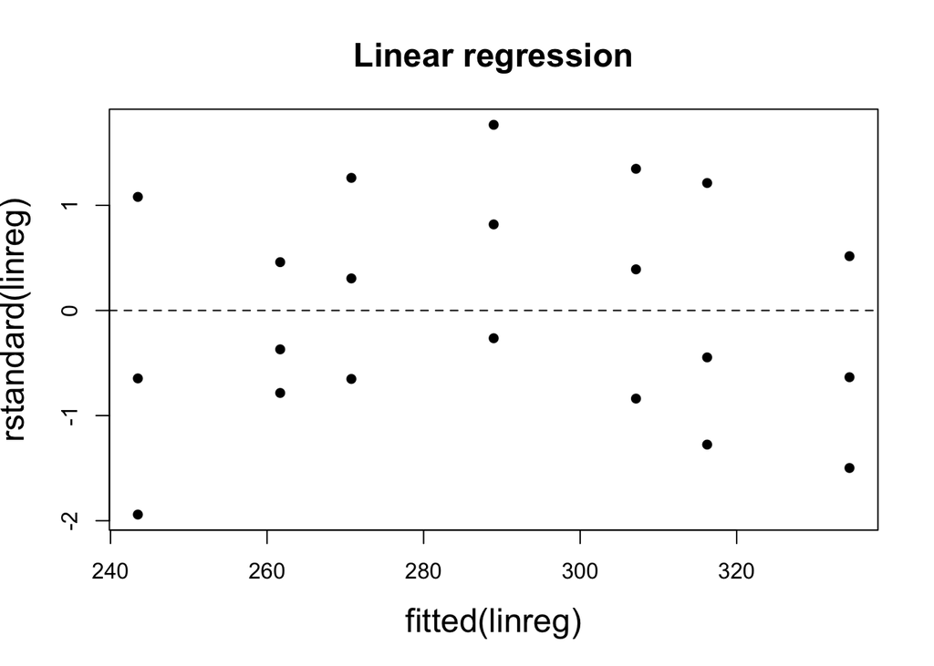

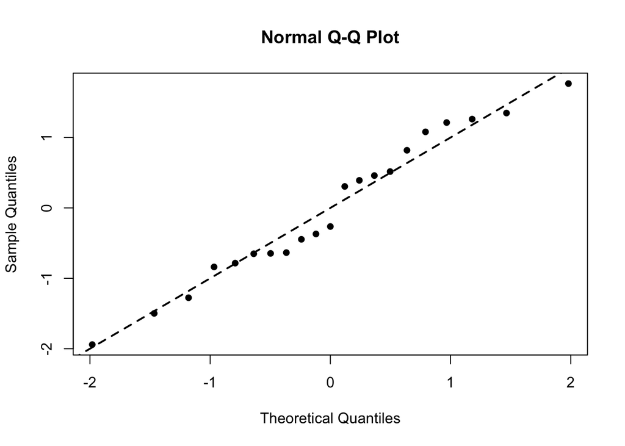

```r
plot(fitted(linreg), rstandard(linreg), pch = 16, main = "Linear regression", cex.main = 1.5, cex.lab = 1.5)
abline(h = 0, lty = 2)
qqnorm(rstandard(linreg), pch = 16)
abline(0, 1, lwd = 2, lty = 2)
```

**Konklusion:**

- Der ses et svag mønster på residualplottet, som kan tyde på, at den lineære struktur af middelværdien ikke passer helt godt på data. Residualerne ligger ikke lige godt omkring 0 for alle fittede værdier.
- Spredningen på residualplottet ser ud til at være ens for alle fittede værdier.
- Punkterne på QQ-plottet afviger ikke systematisk fra den rette linje, så antagelsen om at residualerne/fejlene er normalfordelte virker rimelige.

### For ensidet ANOVA

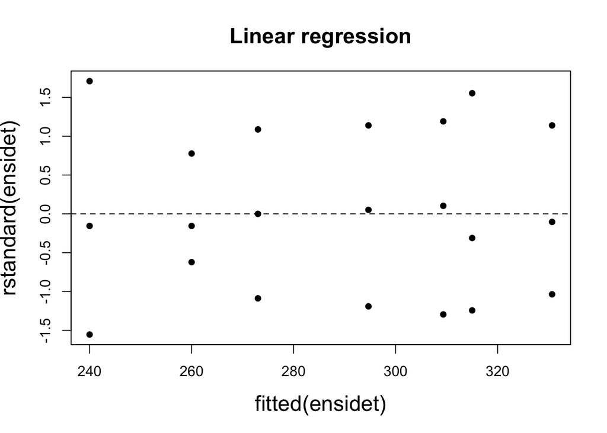

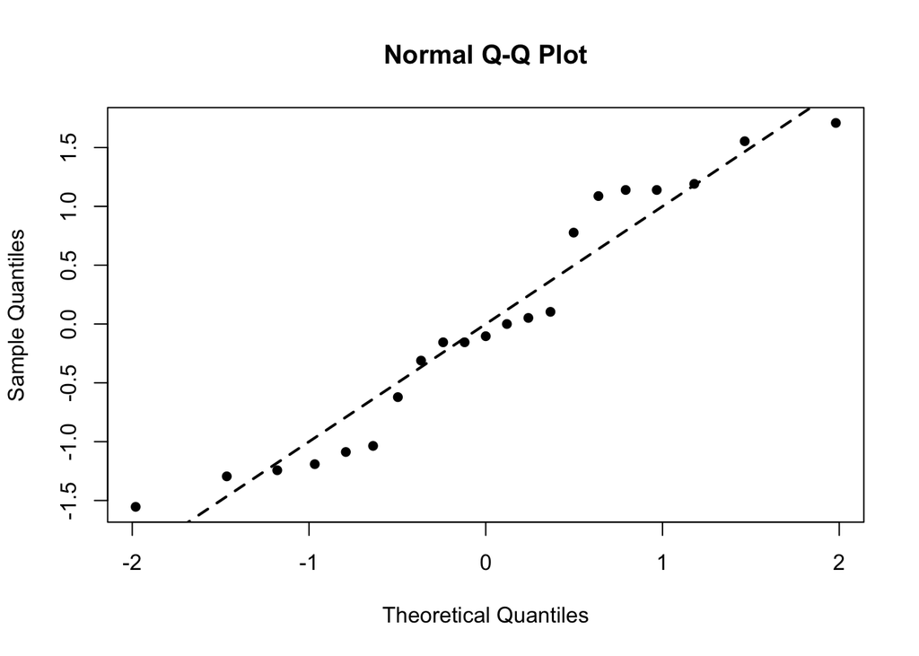

```r
plot(fitted(ensidet), rstandard(ensidet), pch = 16, main = "Linear regression", cex.main = 1.5, cex.lab = 1.5)
abline(h = 0, lty = 2)
qqnorm(rstandard(ensidet), pch = 16)
abline(0, 1, lwd = 2, lty = 2)
```

**Konklusion:**

- Residualerne ligger pænt omkring 0 for alle fittede værdier.
- Spredningen på residualplottet ser ud til at være ens for alle fittede værdier.
- Punkterne på QQ-plottet afviger ikke systematisk fra den rette linje, så antagelsen om at residualerne/fejlene er normalfordelte virker rimelige.

## Test for linearitet

### … mod den ensidet ANOVA

Den ensidede ANOVA estimerer et gruppegennemsnit, for hver at de grupper (her: temperaturer) der optræder i datasættet. Middelværdien af responsen (her: frekvensen `freq`) for en observation er (populations)gennemsnittet for den gruppe (dvs. tempereatur), som hører til observationen. Men der er ikkke nogen restriktioner på, hvordan gruppegennemsnittene svarende til forskellige temperatur-grupper skal høre sammen, når vi blot laver en ensidet variansanalyse (ANOVA).

Når vi laver en lineær regressionsmodel, så laver vi en meget kraftig antagelse om, at den den forventede værdi af responsen (her: frekvensen `freq`) skal være en lineær funktion af temperaturen. Specielt skal den forventede værdi af `freq` for temperaturerne 22 og 23 grader ligge lige så tæt på hinanden som den forventede værdi for temperaturerne 27 og 28. I modsætning til for den ensidede ANOVA, så er der altså en *restriktion på* hvordan de forventede værdier (også kaldet middelværdierne) for de forskellige temperaturer skal hænge sammen.

Da den lineære regressionsmodel kan opfattes som en ensidet ANOVA, hvor man har lagt yderligere restriktioner på middelværdier/gruppegennemsnit, så kan vi bruge et F-test (jf. forelæsning og R-program til 23/9-2019) til at **teste** om **den lineære regressionsmodel** giver en fornuftig beskrivelse af data. Hvis vi forkaster hypotesen, så er konklusionen at linearitetsantagelsen i den lineære regressionsmodel ikke er i overensstemmelse med de observerede data.

```r
anova(linreg, ensidet)
```

```
## Analysis of Variance Table
##
## Model 1: freq ~ temp
## Model 2: freq ~ tempFac
##   Res.Df  RSS Df Sum of Sq      F Pr(>F)
## 1     19 1089
## 2     14  870  5    219.02 0.7049 0.6292
```

**Konklusion:**

- F-teststørrelsen for sammenligning af nulmodellen (lineær regression) mod den fulde model (ensidet ANOVA) beregnes til 0.7049.
- Under nulmodellen vil F-teststørrelsen være F-fordelt med (k - 2, n - k)-frihedsgrader, hvor
  - `n = 21`: er antallet af observationer
  - `k = 7`: er antallaet af parametre under den fulde model (her er det blot antal grupper i den ensidede ANOVA)
  - `2`-tallet optræder fordi der er 2 parametre i nulmodellen (den lineære regressionsmodel har en skæring og en hældning)
- R oversætter F-teststørrelsen til en p-værdi på 0.6292 (men udregn evt. selv følgende i R: `1 - pf(0.7049, 7 - 2, 21 - 7)`)
- Data giver ikke anledning til at forkaste nulhypotesen / linearitetshypotesen.

### … mod en kvadratisk regressionsmodel

Det er også muligt at test hypotese om, at middelværdien af `freq` er en lineær funktion af temperaturen (`temp`) ved at **sammenligne den lineære regressionsmodel med en kvadratisk regressionsmodel**.

En kvadratisk regressionsmodel siger, at middelværdien er givet ved

$$\alpha + \beta \cdot \texttt{temp}_i + \delta \cdot \texttt{temp}_i^2.$$
Den lineære regressionsmodel er et specialtilfælde af den kvadratiske regressionsmodel svarende til at

$$\delta = 0.$$

Vi kan udføre testet for hypotesen på to måder

- 1. som et t-test ved at aflæse ud fra `summary()` af den kvadratiske regressionsmodel i den linje der vedrører estimatet for parameteren $\delta$
- 2. ved at opfatte den kvadratiske regressionsmodel som den *fulde model* og den lineære regressionsmodel som *nulmodellen* og udføre testet som et F-test.

**1. som t-test**

```r
kvreg <- lm(freq ~ temp + I(temp^2), data=eels)
summary(kvreg)
```

```
##
## Call:
## lm(formula = freq ~ temp + I(temp^2), data = eels)
##
## Residuals:
##     Min      1Q  Median      3Q     Max
## -9.7970 -6.0849 -0.0849  7.1334 11.8361
##
## Coefficients:
##              Estimate Std. Error t value Pr(>|t|)
## (Intercept) -126.2886   102.3259  -1.234  0.23301
## temp          24.3930     8.2877   2.943  0.00869 **
## I(temp^2)     -0.3060     0.1655  -1.849  0.08092 .
## ---
## Signif. codes:  0 '***' 0.001 '**' 0.01 '*' 0.05 '.' 0.1 ' ' 1
##
## Residual standard error: 7.13 on 18 degrees of freedom
## Multiple R-squared:  0.9541, Adjusted R-squared:  0.949
## F-statistic: 187.1 on 2 and 18 DF,  p-value: 9.048e-13
```

Vi aflæser, at

- estimatet for det kvadratiske led bliver: $\hat{\delta} = -0.3060$
- at t-teststørrelsen for test af hypotesen $\delta = 0$ bliver: -1.849
- at p-værdien ved opslag i en t-fordeling med $18$ frihedsgrader (`degrees of freedom`) bliver: 0.08092

På et 5 % signifikansniveau vil man derfor ikke forkaste nulhypotesen. Linearitetsantagelsen virker altså rimelig i forhold til fx. en antagelse om, at sammenhængen bør modelleres ved en kvadratisk funktion (dvs. et 2.gradspolynomium).

**2. som F-test**

```r
anova(linreg, kvreg)
```

```
## Analysis of Variance Table
##
## Model 1: freq ~ temp
## Model 2: freq ~ temp + I(temp^2)
##   Res.Df     RSS Df Sum of Sq      F  Pr(>F)
## 1     19 1089.02
## 2     18  915.16  1    173.86 3.4196 0.08092 .
## ---
## Signif. codes:  0 '***' 0.001 '**' 0.01 '*' 0.05 '.' 0.1 ' ' 1
```

- F-teststørrelsen for sammenligning af nulmodellen (lineær regression) mod den fulde model (kvadratisk ANOVA) beregnes til 3.4196.
- Under nulmodellen vil F-teststørrelsen være F-fordelt med (k - 2, n - k)-frihedsgrader, hvor
  - `n = 21`: er antallet af observationer
  - `k = 3`: er antallaet af parametre under den fulde model (her er det de tre parametre i den kvadratiske regressionsmodel)
  - `2`-tallet optræder fordi der er 2 parametre i nulmodellen (den lineære regressionsmodel har en skæring og en hældning)
- R oversætter F-teststørrelsen til en p-værdi på 0.08092 (men udregn evt. selv følgende i R: `1 - pf(3.4196, 3 - 2, 21 - 3)`)
- Data giver ikke anledning til at forkaste nulhypotesen / linearitetshypotesen.